# Flugpreis Vorhersage - Kaufen oder Warten?

## Projektarbeit Data Mining

### Wintersemester 2021/22

### Gruppe G:

Max Grundmann - s0559326

### Inhalte

1. Exploratory Data Analysis (EDA)
2. Datenvorbereitung ### 3. Modelauswahl
3. Auswertungen

Dieses Notebook widmet sich der Auswahl von zwei geeigneten Machine Learning Modellen und deren Hyperparametertuning.

#### Benötigte Bibliotheken laden

```python
import pandas as pd
import numpy as np
from numpy import mean
from numpy import std
import os
from random import sample
import matplotlib.pyplot as plt
import pickle

from sklearn.model_selection import KFold
from sklearn.model_selection import RepeatedStratifiedKFold
from sklearn.model_selection import cross_val_score
from sklearn.model_selection import RandomizedSearchCV, GridSearchCV
from sklearn.linear_model import LogisticRegression
from sklearn import tree
from sklearn.ensemble import RandomForestClassifier
from sklearn.svm import SVC
from sklearn.neighbors import KNeighborsClassifier
from sklearn.naive_bayes import GaussianNB
from sklearn import metrics
from sklearn.model_selection import train_test_split
from sklearn.ensemble import AdaBoostClassifier
from sklearn.ensemble import GradientBoostingClassifier
from sklearn.ensemble import BaggingClassifier
from sklearn.utils import compute_class_weight
from sklearn.metrics import roc_auc_score

from xgboost import XGBClassifier

import tensorflow as tf
from keras.models import load_model
from tensorflow import keras
from keras.layers import Dense, Dropout
from keras.models import Sequential
from keras.callbacks import EarlyStopping, ModelCheckpoint, ReduceLROnPlateau
```

#### Vorbereitete Daten laden

```python
# Bestimmt die Anzahl der Schritte der Preishistorie
n = 15

dirname = os.getcwd()
filename = os.path.join(dirname, f'../Data/prepped/train_set_n{n}.csv')

try:
    training_data = pd.read_csv(filename, index_col=0)
except FileNotFoundError as e:
    print('Datei konnte nicht gefunden werden.')
```

Daten in Trainings- und Testdaten aufteilen. 80% Trainingsdaten, 20% Testdaten Stratify = Yes stellt außerdem sicher, dass das Verhältnis der Klassen in beiden Datensätzen gleich ist.

```python
# Daten in Trainings- und Testdaten aufteilen
y = training_data['buy']
X = training_data.drop(columns=['buy'], axis=1)
X.columns = X.columns.map(str)

for i in range(n):
    # Preishistorie mit aktuellem Preis auffüllen, falls nicht vorhanden
    X[str(i)] = np.where(X[str(i)].isnull(), X.Price_In_Eur, X[str(i)])

X = X.fillna(0)
x_train, x_test, y_train, y_test = train_test_split(X, y, test_size=0.2, random_state=4, stratify=y)
```

#### Auswahl eines ML-Verfahrens

Folgenden Methode dient dem Automatisierten Training und Evaluierung eines ML-Modells. Ziel ist es, eine Baseline für mehrere unterschiedliche Verfahren zu etablieren. Das beste Modell wird anschließend über Hyperparameter Tuning weiter optimiert.

```python
def evaluate_model(model, x_train, y_train, x_test, y_test, fit=True):
    if fit:
        model = model.fit(x_train, y_train)

    train_score = model.score(x_train, y_train)
    print('Training Score:', train_score)

    predicted = pd.DataFrame(model.predict(x_test))

    test_score = metrics.accuracy_score(y_test, predicted)
    print('Test Score:', test_score)

    print(metrics.classification_report(y_test, predicted))
    return train_score, test_score
```

Die Support Vector Machine wurde im weiteren Vorgehen nicht berücksichtigt, da die Trainingszeiten unverhältnismäßig lag dauern. Das dürfte darin begründet liegen, dass die Trainingskomplexität einer SVM bei O(n^2) liegt und entsprechend stark bzw. schlecht mit der Anzahl an Trainingsdaten skaliert. Entsprechend limitiert vermutlich auch mein Arbeitsspeicher die Berechnung.

```python
list_of_models = [RandomForestClassifier(),
                # SVC(kernel='linear'),
                  XGBClassifier(),
                  AdaBoostClassifier(),
                  GradientBoostingClassifier(),
                  tree.DecisionTreeClassifier(max_depth=10),
                  LogisticRegression(),
                  BaggingClassifier(),
                  KNeighborsClassifier(n_neighbors=5),
                  GaussianNB()]

scores = {}

for model in list_of_models:
    print(str(model)[:13])
    train_acc, test_acc = evaluate_model(model, x_train, y_train, x_test, y_test)
    scores[str(model)[:13]] = {'train_accurary' : train_acc, 'test_accuracy': test_acc}
    print('-------------------------------------------------------------------------------')
```

```
RandomForestC
Training Score: 0.9998953646541802
Test Score: 0.9104932735426009
              precision    recall  f1-score   support

           0       0.91      0.98      0.94     12981
           1       0.90      0.67      0.77      3744

    accuracy                           0.91     16725
   macro avg       0.91      0.83      0.86     16725
weighted avg       0.91      0.91      0.91     16725

-------------------------------------------------------------------------------
XGBClassifier
[15:10:31] WARNING: C:/Users/Administrator/workspace/xgboost-win64_release_1.5.1/src/learner.cc:1115: Starting in XGBoost 1.3.0, the default evaluation metric used with the objective 'binary:logistic' was changed from 'error' to 'logloss'. Explicitly set eval_metric if you'd like to restore the old …
```

```
Training Score: 0.9311648903571055
Test Score: 0.8916591928251121
              precision    recall  f1-score   support

           0       0.90      0.96      0.93     12981
           1       0.84      0.64      0.73      3744

    accuracy                           0.89     16725
   macro avg       0.87      0.80      0.83     16725
weighted avg       0.89      0.89      0.89     16725

-------------------------------------------------------------------------------
AdaBoostClass
Training Score: 0.8275310542758487
Test Score: 0.8243946188340807
              precision    recall  f1-score   support

           0       0.84      0.95      0.89     12981
           1       0.70      0.38      0.49      3744

    accuracy                           0.82     16725
   macro avg       0.77      0.67      0.69     16725
weighted avg       0.81      0.82      0.80     16725

-------------------------------------------------------------------------------
GradientBoost
Training Score: 0.8428975022048162
Test Score: 0.8383856502242153
              precision    recall  f1-score   support

           0       0.84      0.97      0.90     12981
           1       0.80      0.37      0.51      3744

    accuracy                           0.84     16725
   macro avg       0.82      0.67      0.71     16725
weighted avg       0.83      0.84      0.81     16725

-------------------------------------------------------------------------------
DecisionTreeC
Training Score: 0.8576211901523192
Test Score: 0.8394020926756353
              precision    recall  f1-score   support

           0       0.85      0.96      0.90     12981
           1       0.76      0.42      0.54      3744

    accuracy                           0.84     16725
   macro avg       0.80      0.69      0.72     16725
weighted avg       0.83      0.84      0.82     16725

-------------------------------------------------------------------------------
LogisticRegre
```

```
Training Score: 0.81365939700145
Test Score: 0.8123766816143497
              precision    recall  f1-score   support

           0       0.83      0.96      0.89     12981
           1       0.68      0.30      0.42      3744

    accuracy                           0.81     16725
   macro avg       0.75      0.63      0.65     16725
weighted avg       0.79      0.81      0.78     16725

-------------------------------------------------------------------------------
BaggingClassi
Training Score: 0.9943496913257298
Test Score: 0.9080418535127055
              precision    recall  f1-score   support

           0       0.91      0.97      0.94     12981
           1       0.88      0.68      0.77      3744

    accuracy                           0.91     16725
   macro avg       0.90      0.83      0.86     16725
weighted avg       0.91      0.91      0.90     16725

-------------------------------------------------------------------------------
KNeighborsCla
Training Score: 0.8742582101376702
Test Score: 0.805321375186846
              precision    recall  f1-score   support

           0       0.84      0.93      0.88     12981
           1       0.61      0.37      0.46      3744

    accuracy                           0.81     16725
   macro avg       0.72      0.65      0.67     16725
weighted avg       0.79      0.81      0.79     16725

-------------------------------------------------------------------------------
GaussianNB()
Training Score: 0.7770968175906964
Test Score: 0.7766816143497758
              precision    recall  f1-score   support

           0       0.79      0.97      0.87     12981
           1       0.51      0.11      0.18      3744

    accuracy                           0.78     16725
   macro avg       0.65      0.54      0.53     16725
weighted avg       0.73      0.78      0.72     16725

-------------------------------------------------------------------------------
```

```python
results = pd.DataFrame(scores).transpose()
results.rename(columns={'index': 'model'},  inplace=True)
results.sort_values(by=['test_accuracy'], axis=0, ascending=False, inplace=True)
results
```

|  | train_accurary | test_accuracy |
| --- | --- | --- |
| RandomForestC | 0.999895 | 0.910493 |
| BaggingClassi | 0.994350 | 0.908042 |
| XGBClassifier | 0.931165 | 0.891659 |
| DecisionTreeC | 0.857621 | 0.839402 |
| GradientBoost | 0.842898 | 0.838386 |
| AdaBoostClass | 0.827531 | 0.824395 |
| LogisticRegre | 0.813659 | 0.812377 |
| KNeighborsCla | 0.874258 | 0.805321 |
| GaussianNB() | 0.777097 | 0.776682 |

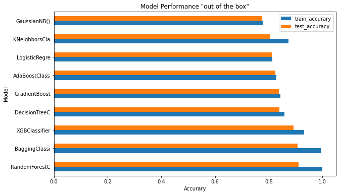

```python
plt.rcParams["figure.figsize"] = [10, 6]

results.plot(kind='barh')
plt.title('Model Performance "out of the box"')
plt.ylabel("Model")
plt.xlabel("Accurary")
plt.savefig("../Ressources/model_performance_comp.png", edgecolor='white')
```

#### Cross-Validation Baseline

Zusätzlich habe ich nochmal die vier vielversprechendsten Classifier mit Kreuzvalidierung getestet.

```python
def display_scores(scores):
    print("Scores:", scores)
    print("Mean:", scores.mean())
    print("Standard deviation:", scores.std())
```

```python
def performCrossValidation(model, x_train, y_train, splits=5):
    print(f'{str(model)[:13]} mit splits={splits}')
    cv = RepeatedStratifiedKFold(n_splits=splits, n_repeats=3, random_state=1)
    return cross_val_score(model, x_train, y_train, scoring='accuracy', cv=cv, n_jobs=-1)
```

```python
display_scores(performCrossValidation(RandomForestClassifier(), x_train, y_train))
```

```
RandomForestC mit splits=5
Scores: [0.90747384 0.90358744 0.9103139  0.90568012 0.90350549 0.90627803
 0.90089686 0.90769806 0.90508221 0.90679423 0.90754858 0.9073991
 0.90418535 0.90216741 0.9077659 ]
Mean: 0.9057584358028165
Standard deviation: 0.0024218930528767243
```

```python
display_scores(performCrossValidation(BaggingClassifier(), x_train, y_train))
```

```
BaggingClassi mit splits=5
Scores: [0.9058296  0.89828102 0.90523169 0.90179372 0.89775021 0.90351271
 0.89753363 0.90201794 0.90127055 0.90066522 0.90239163 0.90007474
 0.90007474 0.90059791 0.90380447]
Mean: 0.9013886508216086
Standard deviation: 0.0024327888943376074
```

```python
display_scores(performCrossValidation(XGBClassifier(), x_train, y_train))
```

```
XGBClassifier mit splits=5
Scores: [0.89394619 0.88856502 0.88811659 0.88527653 0.8928171  0.8887145
 0.89080717 0.88998505 0.89050822 0.89042529 0.89043348 0.89424514
 0.88908819 0.88834081 0.88780925]
Mean: 0.8899385702623224
Standard deviation: 0.0023195638820190964
```

```python
display_scores(performCrossValidation(tree.DecisionTreeClassifier(max_depth=10), x_train, y_train))
```

```
DecisionTreeC mit splits=5
Scores: [0.84297459 0.84446936 0.84431988 0.8357997  0.84206592 0.84125561
 0.84080717 0.84252616 0.84050822 0.84602736 0.84387145 0.84020927
 0.8416293  0.84237668 0.84453248]
Mean: 0.842224876062565
Standard deviation: 0.0023695217789564196
```

Auch hier liefert der Random Forest Classifier ohne weitere Anpassungen die besten Ergebnisse.

### Hyperparameter Tuning eines Random Forest Classifiers

Im einem Vergleich ohne jegliches Hyperparameter Tuning hat der Random Forest Classifier für den Datensatz die höchste Test-Genauigkeit erzielt. Allerdings hat sich bereits dort gezeigt, dass der Classifier ohne weiteres Tuning stark zum overfitting neigt, was an einer Trainingsgenauigkeit von 99% deutlich wird. Für das weitere Tuning wird daher eine K-Fold Cross-Validation mit K=5 durchgeführt.

Da die beiden Klassen Kaufen und Warten sehr ungleich verteilt sind, würde ein naives Modell, das nur Warten vorhersagt, bereits eine Accuracy von 77,6% erreichen. Um dem entgegen zuwirken, berechne ich hier die Gewichtung der beiden Klassen, um diese dem Modell übergeben zu können.

```python
classWeight = compute_class_weight(class_weight = 'balanced',
                                   classes=np.unique(y),
                                    y=y)
classWeight = dict(enumerate(classWeight))
```

#### Randomized Grid Search mit CV für Random Forrest Classfier

Aus Performance-Gründen habe ich die finale Grid-Suche auf einer Google Colab Instanz laufen lassen, daher entsprechen die hier ausgegebenen Outputs nicht unbedingt dem finalen Model.

```python
# Number of trees in random forest
n_estimators = [int(x) for x in np.linspace(start = 50, stop = 250, num = 50)]
# Number of features to consider at every split
max_features = ['auto', 'sqrt', 0.5, 2]
# Maximum number of levels in tree
max_depth = [int(x) for x in np.linspace(10, 110, num = 11)]
max_depth.append(None)
# Minimum number of samples required to split a node
min_samples_split = [2, 5, 10]
# Minimum number of samples required at each leaf node
min_samples_leaf = [1, 2, 4]
# Method of selecting samples for training each tree
bootstrap = [True, False]

random_grid = {'n_estimators': n_estimators,
               'max_features': max_features,
               'max_depth': max_depth,
               'min_samples_split': min_samples_split,
               'min_samples_leaf': min_samples_leaf,
               'bootstrap': bootstrap}
```

```python
rf = RandomForestClassifier(class_weight=classWeight, n_jobs=-1)

rf_random = RandomizedSearchCV(estimator = rf,
                               param_distributions = random_grid,
                               n_iter = 10,
                               cv = 5,
                               verbose=99,
                               random_state=42,
                               scoring='accuracy',
                               n_jobs = -1)

rf_random.fit(x_train, y_train)
rf_random.best_params_
```

```
Fitting 5 folds for each of 10 candidates, totalling 50 fits
```

```
{'n_estimators': 229,
 'min_samples_split': 10,
 'min_samples_leaf': 2,
 'max_features': 0.5,
 'max_depth': 90,
 'bootstrap': False}
```

Modell auf Basis der besten Parameter trainieren

```python
rf_model = RandomForestClassifier(
    n_estimators= 150,
    min_samples_split= 10,
    max_features=0.5,
    max_depth= 32,
    n_jobs=-1,
    bootstrap= False,
    class_weight=classWeight)

rf_model.fit(x_train, y_train)
```

```
RandomForestClassifier(bootstrap=False,
                       class_weight={0: 0.6441931408498444,
                                     1: 2.2337856608612032},
                       max_depth=32, max_features=0.5, min_samples_split=10,
                       n_estimators=150, n_jobs=-1)
```

```python
rf_model = RandomForestClassifier(
    n_estimators= 229,
    min_samples_split= 10,
    min_samples_leaf=2,
    max_features=0.5,
    max_depth= 90,
    n_jobs=-1,
    bootstrap= False,
    class_weight=classWeight)

rf_model.fit(x_train, y_train)
```

```
RandomForestClassifier(bootstrap=False,
                       class_weight={0: 0.6441931408498444,
                                     1: 2.2337856608612032},
                       max_depth=90, max_features=0.5, min_samples_leaf=2,
                       min_samples_split=10, n_estimators=229, n_jobs=-1)
```

```python
evaluate_model(rf_model, x_train, y_train, x_test, y_test, fit=False)
```

```
Training Score: 0.9975335954199614
Test Score: 0.9283707025411061
              precision    recall  f1-score   support

           0       0.95      0.96      0.95     12981
           1       0.86      0.82      0.84      3744

    accuracy                           0.93     16725
   macro avg       0.90      0.89      0.90     16725
weighted avg       0.93      0.93      0.93     16725
```

```
(0.9975335954199614, 0.9283707025411061)
```

```python
display_scores(performCrossValidation(rf_model, x_train, y_train))
```

```
RandomForestC mit splits=5
Scores: [0.92174888 0.92369208 0.92346786 0.92727952 0.92032289 0.92361734
 0.92242152 0.92227205 0.92481315 0.92398535 0.92421525 0.9254858
 0.92085202 0.92212257 0.92570446]
Mean: 0.9234667165555879
Standard deviation: 0.0018318470583025275
```

### Finetuning mit Grid Search

```python
# Number of trees in random forest
n_estimators = [200,300,400]
# Number of features to consider at every split
max_features = [0.25, 0.5, 0.75]
# Maximum number of levels in tree
max_depth = [70, 90, 110]
# Minimum number of samples required to split a node
min_samples_split = [6, 8, 10]
# Minimum number of samples required at each leaf node
min_samples_leaf = [1, 2, 3]
# Method of selecting samples for training each tree
bootstrap = [True, False]

search_grid = {'n_estimators': n_estimators,
               'max_features': max_features,
               'max_depth': max_depth,
               'min_samples_split': min_samples_split,
               'min_samples_leaf': min_samples_leaf,
               'bootstrap': bootstrap}
```

```python
rf = RandomForestClassifier(class_weight=classWeight, n_jobs=-1)

rf_grid = GridSearchCV(rf,
                        search_grid,
                        cv = 5,
                        verbose=99,
                        n_jobs = -1,
                        refit= True)

rf_grid.fit(x_train, y_train)

rf_grid.best_params_
```

[output not shown]

```
{'bootstrap': False,
 'max_depth': 70,
 'max_features': 0.75,
 'min_samples_leaf': 1,
 'min_samples_split': 10,
 'n_estimators': 300}
```

Finales Modell trainieren

```python
rf_model = RandomForestClassifier(
    n_estimators= 300,
    min_samples_split= 10,
    min_samples_leaf=1,
    max_features=0.75,
    max_depth= 70,
    n_jobs=-1,
    bootstrap= False,
    class_weight=classWeight)

rf_model.fit(x_train, y_train)
evaluate_model(rf_model, x_train, y_train, x_test, y_test, fit=False)
```

```
Training Score: 0.9984454177192484
Test Score: 0.9279521674140508
              precision    recall  f1-score   support

           0       0.94      0.96      0.95     12981
           1       0.87      0.80      0.83      3744

    accuracy                           0.93     16725
   macro avg       0.91      0.88      0.89     16725
weighted avg       0.93      0.93      0.93     16725
```

```
(0.9984454177192484, 0.9279521674140508)
```

```python
model_save_path = '../Models/final_models/random_forest_v4.pkl'
pickle.dump(rf_model, open(model_save_path, 'wb'))
```

```python
display_scores(performCrossValidation(rf_model, x_train, y_train))
```

```
RandomForestC mit splits=5
Scores: [0.92346786 0.92032885 0.92100149 0.92331839 0.91867853 0.92436472
 0.91853513 0.91980568 0.91973094 0.92114508 0.92219731 0.9215994
 0.92025411 0.92100149 0.92174303]
Mean: 0.921144801029568
Standard deviation: 0.0016400535208975536
```

#### ROC & AUC

```python
print("ROC Train:", roc_auc_score(y_train, rf_model.predict(x_train)))
```

```
ROC Train: 0.9991044776119403
```

```python
print("ROC Test:", roc_auc_score(y_test, rf_model.predict(x_test)))
```

```
ROC Test: 0.88364706849656
```

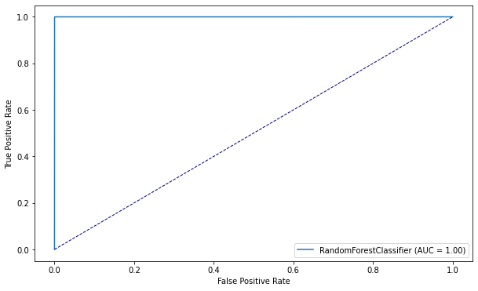

```python
# Training Set
plt.rcParams["figure.figsize"] = [10, 6]
metrics.plot_roc_curve(rf_model, x_train, y_train)
plt.plot([0, 1], [0, 1], color="navy", lw=1, linestyle="--")
plt.xlabel("False Positive Rate")
plt.ylabel("True Positive Rate")
plt.savefig('../Ressources/auc_roc_kurve.png')
```

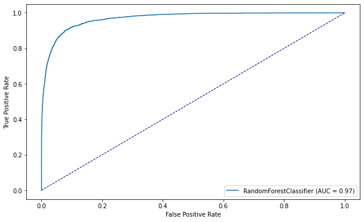

```python
# Test Set
plt.rcParams["figure.figsize"] = [10, 6]
metrics.plot_roc_curve(rf_model, x_test, y_test)
plt.plot([0, 1], [0, 1], color="navy", lw=1, linestyle="--")
plt.xlabel("False Positive Rate")
plt.ylabel("True Positive Rate")
plt.savefig('../Ressources/auc_roc_kurve.png')
```

#### Feature Importance

Die nachfolgende Grafik zeigt die Wichtigkeit der einzelnen Features für den trainierten Random Forest Classifier. Es wird deutlich, dass besonders die beiden Spalten Price_In_Eur und days_remaining wichtig sind.

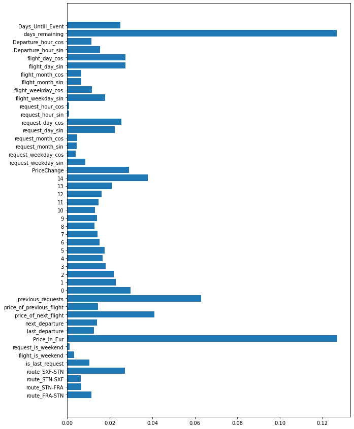

```python
plt.rcParams["figure.figsize"] = [10, 15]
plt.barh(x_train.columns, rf_model.feature_importances_)
plt.savefig('../Ressources/rf_feature_importance.png')
```

```python
pd.DataFrame(list(zip(rf_model.feature_importances_, x_train.columns))).sort_values(by=[0], ascending=False).head(10)
```

|  | 0 | 1 |
| --- | --- | --- |
| 7 | 0.126868 | Price_In_Eur |
| 45 | 0.126622 | days_remaining |
| 12 | 0.063036 | previous_requests |
| 10 | 0.040959 | price_of_next_flight |
| 27 | 0.037897 | 14 |
| 13 | 0.029790 | 0 |
| 28 | 0.028931 | PriceChange |
| 41 | 0.027490 | flight_day_sin |
| 42 | 0.027332 | flight_day_cos |
| 3 | 0.027214 | route_SXF-STN |

Der genaue Zeitpunkt der Anfrage scheint allerdings kaum einen Einfluss auf die Vorhersage zu haben.

```python
pd.DataFrame(list(zip(rf_model.feature_importances_, x_train.columns))).sort_values(by=[0], ascending=False).tail(10)
```

|  | 0 | 1 |
| --- | --- | --- |
| 1 | 0.006676 | route_STN-FRA |
| 39 | 0.006562 | flight_month_sin |
| 2 | 0.006414 | route_STN-SXF |
| 32 | 0.004598 | request_month_cos |
| 31 | 0.004380 | request_month_sin |
| 30 | 0.003882 | request_weekday_cos |
| 5 | 0.003254 | flight_is_weekend |
| 6 | 0.001227 | request_is_weekend |
| 35 | 0.000847 | request_hour_sin |
| 36 | 0.000813 | request_hour_cos |

```python
new_rf = RandomForestClassifier(n_estimators= 150,
 min_samples_split= 8,
 max_features=0.5,
 max_depth= 32,
 bootstrap= False,
 n_jobs = -1,
 class_weight=classWeight)

drop_features = [
    'request_weekday_cos',
    'flight_is_weekend',
    'request_is_weekend',
    'request_hour_sin',
    'request_hour_cos',
    'request_month_sin',
    'request_month_cos',
    'route_STN-SXF',
    'flight_month_sin']

# Drop 5 Features mit der geringsten Wichtigkeit
new_rf.fit(x_train.drop(drop_features, axis=1), y_train)

evaluate_model(new_rf, x_train.drop(drop_features, axis=1), y_train, x_test.drop(drop_features, axis=1), y_test, fit=False)
```

```
Training Score: 0.9994170316447182
Test Score: 0.9301046337817638
              precision    recall  f1-score   support

           0       0.94      0.97      0.96     12981
           1       0.88      0.80      0.84      3744

    accuracy                           0.93     16725
   macro avg       0.91      0.88      0.90     16725
weighted avg       0.93      0.93      0.93     16725
```

```
(0.9994170316447182, 0.9301046337817638)
```

```python
new_rf = RandomForestClassifier(n_estimators= 150,
 min_samples_split= 8,
 max_features=0.5,
 max_depth= 32,
 bootstrap= False,
 n_jobs = -1,
 class_weight=classWeight)


# Drop 5 Features mit der geringsten Wichtigkeit
new_rf.fit(x_train, y_train)

evaluate_model(new_rf, x_train, y_train, x_test, y_test, fit=False)
```

```
Training Score: 0.9994020837381725
Test Score: 0.9301644245142003
              precision    recall  f1-score   support

           0       0.94      0.97      0.96     12981
           1       0.88      0.80      0.84      3744

    accuracy                           0.93     16725
   macro avg       0.91      0.88      0.90     16725
weighted avg       0.93      0.93      0.93     16725
```

```
(0.9994020837381725, 0.9301644245142003)
```

Es zeigt sich, dass die Entfernung der neun Features mit der geringsten Feature Importance praktisch keinen Effekt auf die Accuracy hat.

## 3. Neural Network

Als zweiter Classifier habe ich ein neuronales Netzwerk gewählt, dass ich mit Keras implementiert habe.

```python
n_cols = x_train.shape[1]

model = Sequential()

# Layer hinzufügen
model.add(Dense(512, activation='relu', input_shape=(n_cols,)))

model.add(Dense(1024, activation='relu'))
model.add(Dropout(0.5))

model.add(Dense(512, activation='relu'))
model.add(Dense(128, activation='relu'))
model.add(Dropout(0.5))

model.add(Dense(16, activation='relu'))
model.add(Dense(1, activation='sigmoid'))

# Alternative Optimizer
opt = keras.optimizers.SGD(learning_rate=0.1)
sgd = keras.optimizers.SGD(learning_rate=0.01, decay=1e-6, momentum=0.9, nesterov=True)

model.compile(
    optimizer='adam',
    loss='binary_crossentropy',
    metrics=['accuracy'])

model.summary()
```

```
Model: "sequential_2"
_________________________________________________________________
 Layer (type)                Output Shape              Param #
=================================================================
 dense_6 (Dense)             (None, 512)               24576

 dense_7 (Dense)             (None, 1024)              525312

 dropout_2 (Dropout)         (None, 1024)              0

 dense_8 (Dense)             (None, 512)               524800

 dense_9 (Dense)             (None, 128)               65664

 dropout_3 (Dropout)         (None, 128)               0

 dense_10 (Dense)            (None, 16)                2064

 dense_11 (Dense)            (None, 1)                 17

=================================================================
Total params: 1,142,433
Trainable params: 1,142,433
Non-trainable params: 0
_________________________________________________________________
```

Das finale Netzwerk wurde aus Performance-Gründen auf einer Google Colab GPU Instanz durchgeführt, da dort die Berechnung pro Step um den Faktor 20 schneller geht. Das fertig trainierte Modell wird daher gesondert geladen.

```python
checkpoint_filepath = '../Models/checkpoints/'

model_checkpoint_callback = tf.keras.callbacks.ModelCheckpoint(
    filepath=checkpoint_filepath,
    save_weights_only=True,
    monitor='val_loss',
    mode='auto',
    save_best_only=True)

early_stopping = EarlyStopping(patience=9999, verbose=1)
reduce_lr = ReduceLROnPlateau(monitor='val_accuracy', factor=0.2, patience=20, min_lr=0.00001, verbose=1)

history = model.fit(
    x_train,
    y_train,
    batch_size = 4096,
    validation_data=(x_test, y_test),
    epochs=10,
    class_weight=classWeight,
    callbacks=[early_stopping, reduce_lr, model_checkpoint_callback])
```

Trainiertes Modell laden

```python
model = load_model('../Models/final_models/nn_v5.h5')
history = pickle.load(open('../Models/final_models/nn_history_v5.pkl', 'rb'))
```

### NN Accuracy je Epoch

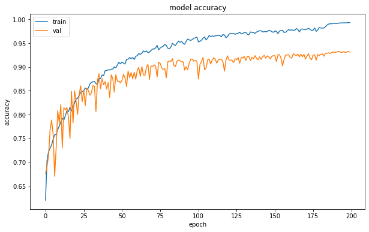

```python
plt.rcParams["figure.figsize"] = [10, 6]
plt.plot(history['accuracy'])
plt.plot(history['val_accuracy'])
plt.title('model accuracy')
plt.ylabel('accuracy')
plt.xlabel('epoch')
plt.legend(['train', 'val'], loc='upper left')
plt.savefig('../Ressources/nn_acc.png')
plt.show()
```

### NN Loss je Epoch

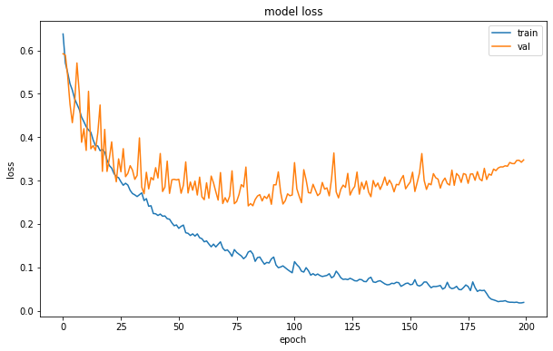

```python
plt.plot(history['loss'])
plt.plot(history['val_loss'])
plt.title('model loss')
plt.ylabel('loss')
plt.xlabel('epoch')
plt.legend(['train', 'val'], loc='upper right')
plt.savefig('../Ressources/nn_loss.png')
plt.show()
```

### ROC-AUC Kurve

```python
from sklearn.metrics import roc_curve
y_pred_keras = model.predict(x_test).ravel()
fpr_keras, tpr_keras, thresholds_keras = roc_curve(y_test, y_pred_keras)
from sklearn.metrics import auc
auc_keras = auc(fpr_keras, tpr_keras)
```

```python
y_pred_rf = rf_model.predict_proba(x_test)[:, 1]
fpr_rf, tpr_rf, thresholds_rf = roc_curve(y_test, y_pred_rf)
auc_rf = auc(fpr_rf, tpr_rf)
```

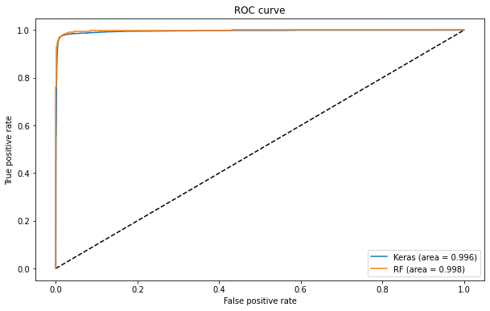

```python
plt.figure(1)
plt.plot([0, 1], [0, 1], 'k--')
plt.plot(fpr_keras, tpr_keras, label='Keras (area = {:.3f})'.format(auc_keras))
plt.plot(fpr_rf, tpr_rf, label='RF (area = {:.3f})'.format(auc_rf))
plt.xlabel('False positive rate')
plt.ylabel('True positive rate')
plt.title('ROC curve')
plt.legend(loc='best')
plt.savefig('../Ressources/roc_auc_rf_vs_nn.png')
plt.show()
```

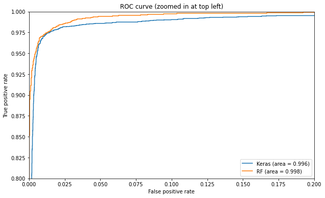

```python
plt.figure(2)
plt.xlim(0, 0.2)
plt.ylim(0.8, 1)
plt.plot([0, 1], [0, 1], 'k--')
plt.plot(fpr_keras, tpr_keras, label='Keras (area = {:.3f})'.format(auc_keras))
plt.plot(fpr_rf, tpr_rf, label='RF (area = {:.3f})'.format(auc_rf))
plt.xlabel('False positive rate')
plt.ylabel('True positive rate')
plt.title('ROC curve (zoomed in at top left)')
plt.legend(loc='best')
plt.savefig('../Ressources/roc_auc_rf_vs_nn_zoomed.png')
plt.show()
```

```python
print("Training Accuracy:",history['train_acc'])
print("Test Accuracy:",history['test_acc'])
```

```
Training Accuracy: 0.9986397624015808
Test Accuracy: 0.9313004612922668
```

```python
predicted = model.predict(x_test)

def zero_or_one(x):
    if x > 0.5:
        return 1
    else:
        return 0
vec = np.vectorize(zero_or_one)

pred = vec(predicted)

print(metrics.classification_report(y_test, pred))
```

```
              precision    recall  f1-score   support

           0       0.96      0.95      0.96     12981
           1       0.84      0.86      0.85      3744

    accuracy                           0.93     16725
   macro avg       0.90      0.91      0.90     16725
weighted avg       0.93      0.93      0.93     16725
```

Die Auswertung der beiden Classifier bezüglich des monetären Gütemaßes sowie die Anwendung auf den Testdatensatz erfolgt im 4. Notebook.